# RQ3 Step 1: The district-year table, the label and the features

Will a district’s consents rise or fall next year?

while True: learn(), Group 8, STAT462

2026-11-20

```r
source(file.path(proj_root, "R", "utils_data.R"))
source(file.path(proj_root, "R", "utils_models.R"))
source(file.path(proj_root, "R", "utils_classify.R"))
library(knitr)

# ---- Settings for this notebook -------------------------------------------
FIRST_YEAR <- 1996   # first feature year: needs five earlier years of history (1991-95)
LAST_YEAR  <- 2024   # last feature year: its label needs 2025, the last complete year
TRAIN_LAST <- 2016   # train on feature years up to 2016, test on 2017-2024

full <- read_csv(file.path(paths$processed, "rq1_district_quarter_full.csv"), show_col_types = FALSE) |>
  filter(ta != "Chatham Islands Territory")
range(full$yq)
```

```
## [1] "1990Q2" "2026Q2"
```

# 1 Purpose

**Research question 3:** *Will a district’s consents rise or fall next year?*

This is a **binary classification** problem. For each district and year we know what happened up to the end of that year, and we predict whether the number of new dwellings consented **next** year will be higher (rise) or not (fall). The pitch proposed logistic regression, linear discriminant analysis (LDA) and a classification tree.

This notebook builds the table (one row per district and year), defines the label, builds the features, and explores them. Models are in Step 2.

# 2 One row per district and year

We add up the quarterly district table from RQ1 into **calendar years**. 1990 is incomplete (it starts in April) and 2026 is incomplete (it ends in June), so complete years run from 1991 to 2025. As in RQ2, the Chatham Islands are left out: about three new dwellings a year give a label that is mostly noise, with many years of no change.

```r
annual <- full |>
  filter(year >= 1991, year <= 2025) |>
  group_by(ta, region, island, is_city, year) |>
  summarise(quarters  = n(),
            dwellings = sum(dwell_n),
            houses    = sum(houses_n),
            h1        = sum(dwell_n[quarter <= 2]),       # January-June
            h2        = sum(dwell_n[quarter >= 3]),       # July-December
            alt_real  = sum(resid_alt_val * real_factor),
            nonres_real = sum(nonres_new_val * real_factor),
            dwell_per_1000 = dwell_per_1000[quarter == 4],  # the 12 months to December
            .groups = "drop")
stopifnot(all(annual$quarters == 4))
c(districts = n_distinct(annual$ta), years = n_distinct(annual$year), rows = nrow(annual))
```

```
## districts     years      rows
##        66        35      2310
```

# 3 The label: rise or fall next year

$$\text{rise}_{d,t} = 1 \text{ if new dwellings}_{d,t+1} > \text{new
dwellings}_{d,t}, \text{ otherwise } 0.$$

We use **new dwellings** (all types), the headline count of the consents data. A year with *exactly* the same number as the year before counts as “not rising”. Those ties are rare and only happen in very small districts.

```r
annual <- annual |>
  group_by(ta) |>
  arrange(year, .by_group = TRUE) |>
  mutate(next_dwellings = lead(dwellings),
         rise = as.integer(next_dwellings > dwellings),
         tie  = next_dwellings == dwellings) |>
  ungroup()

annual |> filter(!is.na(rise)) |>
  summarise(rows = n(), share_rising = mean(rise), ties = sum(tie), share_ties = mean(tie)) |> kable(digits = 3)
```

| rows | share_rising | ties | share_ties |
| --- | --- | --- | --- |
| 2244 | 0.514 | 45 | 0.02 |

# 4 Features: what is known at the end of year *t*

Every feature uses information available on 31 December of year *t*, so the model could have been used at that date to predict year *t* + 1. Nothing from year *t* + 1 is used.

| Feature | Definition | Why it might predict next year |
| --- | --- | --- |
| `log_dwellings` | log(1 + new dwellings in year *t*) | Size; small districts swing more |
| `growth_1y` | log change in dwellings from *t* − 1 to *t* | Momentum (a rise continues) or reversal (a rise is followed by a fall) |
| `growth_2y` | log change from *t* − 2 to *t* | Longer momentum |
| `dev_5y` | log(dwellings in *t*) minus the average log of the previous five years | Above its usual level, a district may fall back (mean reversion) |
| `h2_vs_h1` | log(dwellings July–December ÷ January–June) in year *t* | Direction at the end of the year: a strong second half points upwards |
| `alt_growth` | log change in real residential alteration value | Spending on existing homes as a sign of local demand |
| `nonres_growth` | log change in real non-residential value | Local business investment |
| `multiunit_share` | share of new dwellings that are not stand-alone houses | Apartment and townhouse projects come in lumps, so they make counts jumpy |
| `dwell_per_1000` | new dwellings per 1,000 residents in the year | Building intensity relative to the population |
| `nat_growth_1y` | the same as `growth_1y` for New Zealand as a whole | National cycle |
| `nat_dev_5y` | the same as `dev_5y` for New Zealand | Is the country above its usual level? |
| `nat_h2_vs_h1` | the same as `h2_vs_h1` for New Zealand | National direction at the end of the year |

`+ 1` inside the logs avoids log(0) for districts with no dwellings in a year or half-year.

```r
lg <- function(x) log(x + 1)
mean_prev5 <- function(x) (lag(x, 1) + lag(x, 2) + lag(x, 3) + lag(x, 4) + lag(x, 5)) / 5

nat <- annual |>
  group_by(year) |>
  summarise(nat_dwellings = sum(dwellings), nat_h1 = sum(h1), nat_h2 = sum(h2), .groups = "drop") |>
  arrange(year) |>
  mutate(nat_growth_1y = lg(nat_dwellings) - lag(lg(nat_dwellings)),
         nat_dev_5y    = lg(nat_dwellings) - mean_prev5(lg(nat_dwellings)),
         nat_h2_vs_h1  = log(nat_h2 / nat_h1),
         nat_rise_next = as.integer(lead(nat_dwellings) > nat_dwellings))

rq3 <- annual |>
  group_by(ta) |>
  arrange(year, .by_group = TRUE) |>
  mutate(log_dwellings   = lg(dwellings),
         growth_1y       = log_dwellings - lag(log_dwellings, 1),
         growth_2y       = log_dwellings - lag(log_dwellings, 2),
         dev_5y          = log_dwellings - mean_prev5(log_dwellings),
         h2_vs_h1        = lg(h2) - lg(h1),
         alt_growth      = lg(alt_real) - lag(lg(alt_real)),
         nonres_growth   = lg(nonres_real) - lag(lg(nonres_real)),
         multiunit_share = if_else(dwellings > 0, 1 - houses / dwellings, 0)) |>
  ungroup() |>
  left_join(nat |> select(year, nat_growth_1y, nat_dev_5y, nat_h2_vs_h1, nat_rise_next), by = "year")

# 2025 rows: features are known, the outcome (2026) is not. Kept aside for forecasting (used by the app).
forecast <- rq3 |> filter(year == LAST_YEAR + 1)

rq3 <- rq3 |>
  filter(year >= FIRST_YEAR, year <= LAST_YEAR) |>
  mutate(split = if_else(year <= TRAIN_LAST, "train", "test"))

features <- c("log_dwellings", "growth_1y", "growth_2y", "dev_5y", "h2_vs_h1", "alt_growth", "nonres_growth",
              "multiunit_share", "dwell_per_1000", "nat_growth_1y", "nat_dev_5y", "nat_h2_vs_h1")
c(rows = nrow(rq3), missing_values = sum(is.na(rq3[c(features, "rise")])))
```

```
##           rows missing_values
##           1914              0
```

```r
rq3 |> count(split, name = "rows") |>
  left_join(rq3 |> group_by(split) |> summarise(years = paste(min(year), "to", max(year)), share_rising = mean(rise)),
            by = "split") |> kable(digits = 3, caption = "Train and test district-years")
```

Train and test district-years

| split | rows | years | share_rising |
| --- | --- | --- | --- |
| test | 528 | 2017 to 2024 | 0.477 |
| train | 1386 | 1996 to 2016 | 0.533 |

**Observation.** Every row has every feature, because rows start in 1996: `dev_5y` needs five earlier years (1991–95), and `dwell_per_1000` starts in 1996. The pitch counted 1,742 training rows from 1991. Starting in 1996 gives fewer but complete rows (no imputation). The split is by time again: train on feature years 1996–2016 (labels 1997–2017), test on 2017–2024 (labels 2018–2025).

# 5 How much does the year matter?

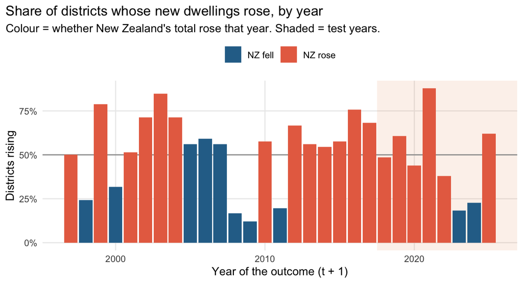

```r
by_year <- rq3 |> group_by(year, split) |>
  summarise(share_rising = mean(rise), nat_rise = first(nat_rise_next), .groups = "drop")

p_year <- ggplot(by_year, aes(year + 1, share_rising)) +
  annotate("rect", xmin = TRAIN_LAST + 1.5, xmax = Inf, ymin = -Inf, ymax = Inf, alpha = 0.1, fill = "#e07a1f") +
  geom_hline(yintercept = 0.5, colour = "grey60") +
  geom_col(aes(fill = factor(nat_rise, labels = c("NZ fell", "NZ rose")))) +
  scale_fill_manual(values = c("NZ fell" = "#2a6f97", "NZ rose" = "#e76f51")) +
  scale_y_continuous(labels = scales::percent) +
  labs(title = "Share of districts whose new dwellings rose, by year",
       subtitle = "Colour = whether New Zealand's total rose that year. Shaded = test years.",
       x = "Year of the outcome (t + 1)", y = "Districts rising", fill = NULL) +
  theme(legend.position = "top")
save_fig(p_year, "fig01_share_rising_by_year", dir = paths$fig_rq3, height = 3.8)
```

```r
# how much of the label's variation is "which year it is"?
summary(lm(rise ~ factor(year), data = rq3 |> filter(split == "train")))$r.squared
```

```
## [1] 0.167832
```

**Observation.** The share of districts rising swings enormously from year to year: from about 12% (2009, during the global financial crisis) to about 88% (2021, the post-COVID boom). Districts mostly rise and fall **together**, with the national building cycle. When New Zealand as a whole rose (red), most districts rose; when it fell (blue), most fell.

Knowing only *which year* it is explains about 17% of the variation in the label (R² of a linear model on year alone). That is a lot for a 0/1 label. It means a large part of the problem is predicting the **national** direction next year, which no district feature can know for certain. This puts a ceiling on how well any model can do, and it is why the national features are included.

The test years are harder than the training years in one respect: they include the sharp turn after the 2021 boom: 88% of districts rose in 2021, but under 25% rose in 2023 and in 2024.

# 6 Features against the label

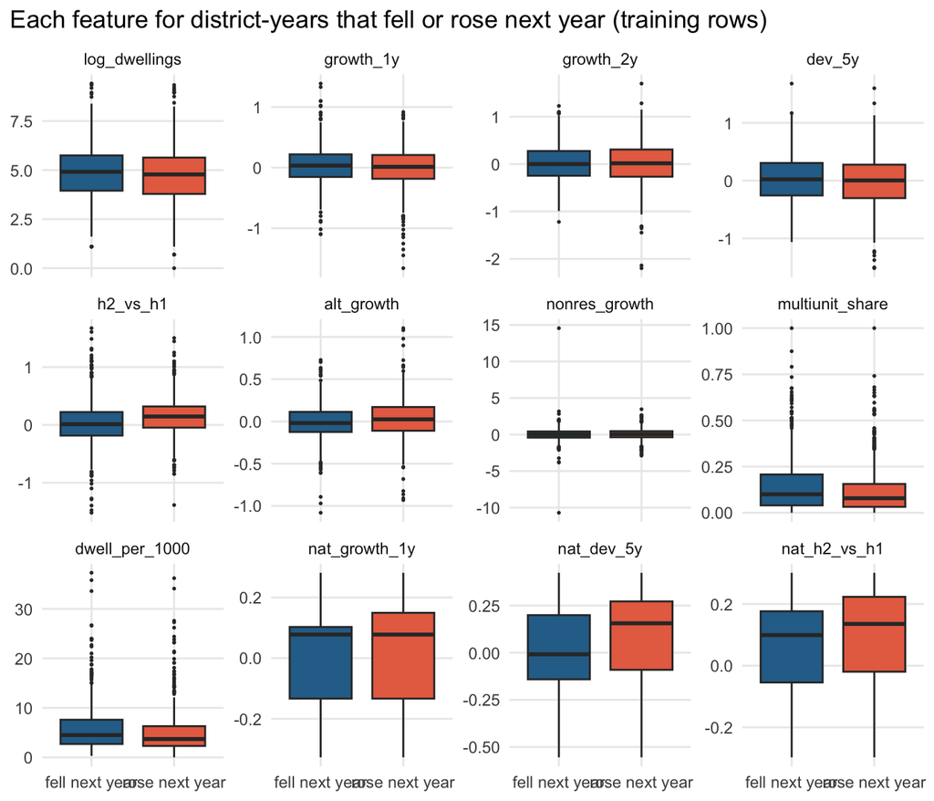

```r
p_box <- rq3 |> filter(split == "train") |>
  select(rise, all_of(features)) |>
  pivot_longer(-rise, names_to = "feature") |>
  mutate(feature = factor(feature, levels = features),
         outcome = factor(rise, levels = 0:1, labels = c("fell next year", "rose next year"))) |>
  ggplot(aes(outcome, value, fill = outcome)) +
  geom_boxplot(outlier.size = 0.3, show.legend = FALSE) +
  facet_wrap(~feature, scales = "free_y", ncol = 4) +
  scale_fill_manual(values = c("fell next year" = "#2a6f97", "rose next year" = "#e76f51")) +
  labs(title = "Each feature for district-years that fell or rose next year (training rows)", x = NULL, y = NULL)
save_fig(p_box, "fig02_features_by_outcome", dir = paths$fig_rq3, height = 6, width = 8.5)
```

A simple way to measure how much each feature *on its own* separates rises from falls is its **AUC**: the probability that a randomly chosen “rise” row has a higher value of the feature than a randomly chosen “fall” row. 0.5 means no separation. Values below 0.5 mean the feature separates in the other direction (lower values go with rises), so we also show max(AUC, 1 − AUC).

```r
uni <- tibble(feature = features) |>
  mutate(auc = map_dbl(feature, \(v) auc(rq3$rise[rq3$split == "train"], rq3[[v]][rq3$split == "train"])),
         separation = pmax(auc, 1 - auc),
         direction = if_else(auc > 0.5, "higher → rise", "higher → fall")) |>
  arrange(desc(separation))
save_tab(uni, "t01_univariate_auc", dir = paths$tab_rq3) |>
  kable(digits = 3, caption = "Single-feature AUC on the training rows")
```

Single-feature AUC on the training rows

| feature | auc | separation | direction |
| --- | --- | --- | --- |
| nat_h2_vs_h1 | 0.623 | 0.623 | higher → rise |
| h2_vs_h1 | 0.608 | 0.608 | higher → rise |
| nat_dev_5y | 0.579 | 0.579 | higher → rise |
| dwell_per_1000 | 0.432 | 0.568 | higher → fall |
| multiunit_share | 0.444 | 0.556 | higher → fall |
| alt_growth | 0.551 | 0.551 | higher → rise |
| nat_growth_1y | 0.538 | 0.538 | higher → rise |
| log_dwellings | 0.468 | 0.532 | higher → fall |
| dev_5y | 0.474 | 0.526 | higher → fall |
| growth_1y | 0.477 | 0.523 | higher → fall |
| nonres_growth | 0.515 | 0.515 | higher → rise |
| growth_2y | 0.494 | 0.506 | higher → fall |

**Observation.** No single feature separates rises from falls well: the best AUC is about 0.62, where 0.5 is guessing. The strongest signals are:

- **End-of-year momentum**, nationally (`nat_h2_vs_h1`) and in the district (`h2_vs_h1`). If the second half of the year was busier than the first, next year tends to be higher.
- **The national level vs its five-year average** (`nat_dev_5y`). Higher goes with rising, so the national cycle shows momentum over a one-year horizon.
- **Building intensity and the multi-unit share** point the other way: districts already building a lot per resident, or relying on apartment and townhouse projects, are slightly more likely to fall next year.
- The district’s **own growth this year** (`growth_1y`, `dev_5y`) has a weak *negative* link: a district that jumped this year is slightly more likely to fall back next year (mean reversion), while the national series shows momentum.

The signal is weak but consistent. Step 2 will show how much the models can combine it.

# 7 Overlap between features (correlation and VIF)

Logistic regression and LDA are both linear models, and their coefficients become unstable when features overlap. We check the variance inflation factor (VIF = 1 / (1 − R²) from regressing each feature on the others; see RQ2 Step 1).

```r
vif_rq3 <- function(df) map_dbl(names(df), function(v)
  1 / (1 - summary(lm(reformulate(setdiff(names(df), v), v), data = df))$r.squared)) |> set_names(names(df))
train_x <- rq3 |> filter(split == "train") |> select(all_of(features))
vif_all <- vif_rq3(train_x)
tibble(feature = names(vif_all), vif = vif_all) |> arrange(desc(vif)) |> kable(digits = 2, caption = "VIF, all twelve features")
```

VIF, all twelve features

| feature | vif |
| --- | --- |
| dev_5y | 4.61 |
| growth_2y | 3.68 |
| nat_growth_1y | 2.71 |
| nat_dev_5y | 2.38 |
| growth_1y | 2.25 |
| log_dwellings | 1.62 |
| dwell_per_1000 | 1.58 |
| nat_h2_vs_h1 | 1.45 |
| multiunit_share | 1.21 |
| alt_growth | 1.14 |
| h2_vs_h1 | 1.10 |
| nonres_growth | 1.02 |

```r
round(cor(train_x$growth_1y, train_x$growth_2y), 2)
```

```
## [1] 0.65
```

**Observation.** No feature reaches the usual warning level of 5. The highest are `dev_5y` (4.6) and `growth_2y` (3.7). These three growth measures overlap by construction: `growth_2y` is this year’s growth plus last year’s, and both are part of `dev_5y`. `growth_2y` is also the weakest feature on its own (AUC 0.51). We drop it, which brings every VIF below 3 and leaves eleven features.

```r
features_final <- setdiff(features, "growth_2y")
vif_final <- vif_rq3(train_x |> select(all_of(features_final)))
tibble(feature = names(vif_final), vif = vif_final) |> arrange(desc(vif)) |>
  save_tab("t02_vif", dir = paths$tab_rq3) |> kable(digits = 2, caption = "VIF, final eleven features")
```

VIF, final eleven features

| feature | vif |
| --- | --- |
| nat_growth_1y | 2.70 |
| dev_5y | 2.53 |
| nat_dev_5y | 2.37 |
| growth_1y | 2.18 |
| log_dwellings | 1.62 |
| dwell_per_1000 | 1.57 |
| nat_h2_vs_h1 | 1.44 |
| multiunit_share | 1.21 |
| alt_growth | 1.14 |
| h2_vs_h1 | 1.10 |
| nonres_growth | 1.02 |

# 8 Save

```r
rq3_model <- rq3 |>
  select(ta, region, island, is_city, year, split, rise, dwellings, next_dwellings, nat_rise_next,
         all_of(features)) |>
  mutate(rise_f = factor(rise, levels = 0:1, labels = c("fall", "rise")))
saveRDS(list(data = rq3_model, features = features_final, all_features = features,
             forecast = forecast |> select(ta, region, island, is_city, year, dwellings, all_of(features))),
        file.path(paths$processed, "rq3_model_data.rds"))
write_csv(rq3_model, file.path(paths$processed, "rq3_model_data.csv"))
dim(rq3_model)
```

```
## [1] 1914   23
```

# 9 Summary of decisions

[output not shown]

**Next (Step 2):** fit and compare classifiers (baselines, logistic regression, LDA, QDA, a classification tree, k-nearest neighbours, lasso logistic regression and a random forest), tuned by time-ordered cross-validation and tested once on 2017–2024.

# 10 Appendix: helper functions

This notebook uses helper functions from `R/utils_data.R`, `R/utils_models.R` and `R/utils_classify.R`, printed here so the document is complete on its own.

```r
# =============================================================================
# R/utils_data.R
# Shared helpers for reading and reshaping Stats NZ data.
# Source this from any Rmd after the project root has been set:
#   source(file.path(proj_root, "R", "utils_data.R"))
# =============================================================================

suppressPackageStartupMessages({
  library(data.table)
  library(tidyverse)
})

# ---- Paths (all relative to the project root) -------------------------------
paths <- list(
  raw_extracted = "data/raw/extracted",
  raw_cgpi      = "data/raw/external/cgpi",
  reference     = "data/reference",
  processed     = "data/processed",
  fig_rq1       = "outputs/figures/rq1",
  tab_rq1       = "outputs/tables/rq1",
  fig_rq2       = "outputs/figures/rq2",
  tab_rq2       = "outputs/tables/rq2"
)

# ---- Reading Stats NZ "Infoshare" long-format CSVs --------------------------
# Every Infoshare file has one row per (series x period). We read only the
# columns that carry information and give them short working names.
#
# Notes
# * `Period` MUST be read as text: as a number, "2025.10" becomes 2025.1,
#   which is indistinguishable from January.
# * integer64 is turned off so that large dollar values come back as doubles
#   (integer64 silently overflows on division).
read_infoshare <- function(file,
                           dir = paths$raw_extracted,
                           keep_status = FALSE) {
  cols <- c("Series_reference", "Period", "Data_value",
            "Series_title_1", "Series_title_2",
            "Series_title_3", "Series_title_4", "Series_title_5")
  if (keep_status) cols <- c(cols, "Status")

  dt <- fread(file.path(dir, file),
              select      = cols,
              colClasses  = list(character = "Period"),
              integer64   = "double",
              na.strings  = c("", "NA"),
              showProgress = FALSE)

  as_tibble(dt) |>
    rename(series  = Series_reference,
           period  = Period,
           value   = Data_value,
           area    = Series_title_1,
           btype   = Series_title_2,
           work    = Series_title_3,
           measure = Series_title_4,
           adjust  = Series_title_5)   # Actual / Seasonally adjusted / Trend (regional files only)
}

# ---- Period helpers ----------------------------------------------------------
# "YYYY.MM" -> integer year / month / calendar quarter
period_year    <- function(p) as.integer(substr(p, 1, 4))
period_month   <- function(p) as.integer(substr(p, 6, 7))
month_quarter  <- function(m) (m - 1L) %/% 3L + 1L

# Label like "2019Q3"
yq_label <- function(year, quarter) paste0(year, "Q", quarter)

# Sequential quarter index (1990Q1 = 1) - handy as a numeric time trend
yq_index <- function(year, quarter) (year - 1990L) * 4L + quarter

# ---- GST ---------------------------------------------------------------------
# Consent values are GST-inclusive. GST was 12.5% from 1 Jul 1989 to
# 30 Sep 2010 and 15% from 1 Oct 2010. Every month in our data is >= 1990,
# so only these two rates apply. Quarter boundaries line up with the change
# (2010Q4 starts on 1 Oct 2010), so a quarter-level rule is exact.
gst_rate <- function(year, quarter) {
  if_else(yq_index(year, quarter) >= yq_index(2010L, 4L), 0.15, 0.125)
}

# ---- Small display helpers ---------------------------------------------------
fmt_int <- function(x) format(round(x), big.mark = ",", scientific = FALSE)
fmt_dol <- function(x) paste0("$", fmt_int(x))
fmt_pct <- function(x, d = 1) paste0(format(round(100 * x, d), nsmall = d), "%")

# ---- Figures -----------------------------------------------------------------
theme_set(theme_minimal(base_size = 11) +
            theme(plot.title.position = "plot",
                  panel.grid.minor = element_blank()))

# Save a ggplot as PNG (for the report) and return it (so it also shows in the Rmd)
save_fig <- function(p, name, dir = paths$fig_rq1, width = 7, height = 4.2) {
  dir.create(dir, recursive = TRUE, showWarnings = FALSE)
  ggsave(file.path(dir, paste0(name, ".png")), p,
         width = width, height = height, dpi = 200, bg = "white")
  p
}

# Save a table as CSV (for the report) and return it
save_tab <- function(df, name, dir = paths$tab_rq1) {
  dir.create(dir, recursive = TRUE, showWarnings = FALSE)
  write_csv(df, file.path(dir, paste0(name, ".csv")))
  df
}
```

```r
# =============================================================================
# R/utils_models.R
# Shared helpers for fitting, tuning and comparing models (Step 3 onwards).
# Source AFTER utils_data.R:
#   source(file.path(proj_root, "R", "utils_data.R"))
#   source(file.path(proj_root, "R", "utils_models.R"))
#
# The idea: every model is written as ONE function
#     fit_predict(train_df, new_df, params)  ->  predictions for new_df
# and the same tuning / scoring code is used for all of them. That way every
# model is judged on exactly the same folds with exactly the same metrics.
# =============================================================================

paths$models_rq1 <- "outputs/models/rq1"

# ---- Metrics -----------------------------------------------------------------
# obs, pred: numeric vectors on the LOG scale.
#   rmse  root mean squared error   (penalises big misses more)
#   mae   mean absolute error       (typical miss)
#   r2    1 - SSE / SST             (share of variance explained, on these rows)
# On the log scale an error of 0.10 is roughly a 10% miss in $/m².
reg_metrics <- function(obs, pred) {
  e <- pred - obs
  tibble(rmse = sqrt(mean(e^2)),
         mae  = mean(abs(e)),
         r2   = 1 - sum(e^2) / sum((obs - mean(obs))^2))
}

# MAPE on the dollar scale: mean |predicted - actual| / actual
mape <- function(obs_dollars, pred_dollars) mean(abs(pred_dollars - obs_dollars) / obs_dollars)

# ---- Time-ordered cross-validation folds ------------------------------------
# "Forward-chaining" (rolling-origin) CV: each fold trains on all years BEFORE a
# validation block and validates on that block. This mimics the real task
# (learn from the past, predict the future) and never lets a model peek ahead.
#   years        : the year of every training row
#   valid_blocks : list of year vectors, one per fold
# Returns a named list of folds, each with $train and $valid row numbers.
make_time_folds <- function(years,
                            valid_blocks = list(2012:2013, 2014:2015, 2016:2017, 2018:2019)) {
  folds <- lapply(valid_blocks, function(b)
    list(train = which(years < min(b)), valid = which(years %in% b)))
  names(folds) <- vapply(valid_blocks, function(b) paste0("valid ", min(b), "-", max(b)), "")
  folds
}

# ---- Generic tuner -----------------------------------------------------------
# fit_predict(train_df, new_df, params) must return either
#   * a numeric vector (one prediction per row of new_df), or
#   * a matrix with one column per value of an "inner" setting that one fit can
#     produce for free (lambda for glmnet, number of rounds for xgboost). The
#     column names hold that setting's value and `inner` names it.
#     The values are rounded to 6 significant figures before grouping: going
#     through column names (text) can change the last digits, and then the
#     same lambda would not match across folds.
# grid: data frame, one row per combination of settings to try.
# Returns list(folds = per-fold scores, summary = mean score per setting,
#              best = the setting with the lowest mean RMSE).
cv_tune <- function(fit_predict, grid, data, folds, response, inner = NULL) {
  grid <- as_tibble(grid)
  if (nrow(grid) == 0) grid <- tibble(.dummy = 1)

  per_fold <- map_dfr(seq_len(nrow(grid)), function(g) {
    params <- as.list(grid[g, , drop = FALSE])
    map_dfr(names(folds), function(fn) {
      f    <- folds[[fn]]
      pred <- fit_predict(data[f$train, ], data[f$valid, ], params)
      pred <- as.matrix(pred)
      if (is.null(colnames(pred))) colnames(pred) <- "0"
      obs  <- data[[response]][f$valid]
      map_dfr(colnames(pred), function(cn)
        reg_metrics(obs, pred[, cn]) |>
          mutate(config = g, inner_value = signif(as.numeric(cn), 6), fold = fn, n_valid = length(obs)))
    })
  })

  summary <- per_fold |>
    group_by(config, inner_value) |>
    summarise(cv_rmse = mean(rmse), cv_rmse_sd = sd(rmse),
              cv_mae = mean(mae), cv_r2 = mean(r2), .groups = "drop") |>
    left_join(grid |> mutate(config = row_number()), by = "config") |>
    select(-any_of(".dummy")) |>
    arrange(cv_rmse)
  if (!is.null(inner)) summary <- rename(summary, !!inner := inner_value)
  else summary <- select(summary, -inner_value)

  list(folds = per_fold, summary = summary, best = summary[1, ])
}

# ---- Design matrix with a fixed set of columns ------------------------------
# glmnet, xgboost and svm need a numeric matrix, not a data frame with factors.
# model.matrix() turns each factor into 0/1 "dummy" columns. Because our factors
# carry ALL their levels, train and test matrices always get the same columns.
make_x <- function(df, rhs) {
  model.matrix(as.formula(paste("~", rhs)), data = df)[, -1, drop = FALSE]  # drop intercept
}

# ---- Timing helper -----------------------------------------------------------
# Runs an expression and returns its value with the elapsed seconds attached.
timed <- function(expr) {
  t0  <- Sys.time()
  out <- force(expr)
  attr(out, "seconds") <- as.numeric(difftime(Sys.time(), t0, units = "secs"))
  out
}

# ---- Summarising tuning results ---------------------------------------------
# res_by_set: a named list (one element per feature set) of cv_tune() results.
# Returns one row per feature set: the best setting found and its CV scores.
settings_text <- function(best) {
  b <- best |> select(-any_of(c("config", "cv_rmse", "cv_rmse_sd", "cv_mae", "cv_r2")))
  if (ncol(b) == 0) return("(none)")
  paste(names(b), signif(unlist(b), 3), sep = " = ", collapse = ", ")
}

summarise_tuning <- function(res_by_set, model) {
  imap_dfr(res_by_set, function(r, set)
    tibble(model = model, set = set,
           cv_rmse = r$best$cv_rmse, cv_rmse_se = r$best$cv_rmse_sd / sqrt(n_distinct(r$folds$fold)),
           cv_mae = r$best$cv_mae, cv_r2 = r$best$cv_r2,
           n_settings_tried = nrow(r$summary),
           best_settings = settings_text(r$best),
           seconds = round(attr(r, "seconds"), 1)))
}

# ---- Refit the best setting on ALL training rows and predict new rows -------
# factory(vars, y) returns a fit_predict function (see cv_tune). For models with
# an inner setting, the prediction column closest to the chosen value is kept.
refit_predict <- function(factory, res_by_set, sets, y, train_df, new_df, inner = NULL) {
  imap(sets, function(vars, set) {
    best <- res_by_set[[set]]$best
    pred <- as.matrix(factory(vars, y)(train_df, new_df, as.list(best)))
    if (!is.null(inner))
      pred <- pred[, which.min(abs(as.numeric(colnames(pred)) - best[[inner]])), drop = FALSE]
    as.numeric(pred)
  })
}
```

```r
# =============================================================================
# R/utils_classify.R
# Shared helpers for classification (RQ3). Source AFTER utils_data.R and
# utils_models.R (which provides make_time_folds):
#   source(file.path(proj_root, "R", "utils_data.R"))
#   source(file.path(proj_root, "R", "utils_models.R"))
#   source(file.path(proj_root, "R", "utils_classify.R"))
# =============================================================================

paths$fig_rq3    <- "outputs/figures/rq3"
paths$tab_rq3    <- "outputs/tables/rq3"
paths$models_rq3 <- "outputs/models/rq3"

# ---- Area under the ROC curve -------------------------------------------------
# Probability that a randomly chosen positive (y = 1) gets a higher predicted
# probability than a randomly chosen negative (y = 0). 0.5 = no better than
# guessing, 1 = perfect ranking. Computed from ranks (the Mann-Whitney statistic);
# ties count as one half.
auc <- function(y, p) {
  n1 <- sum(y == 1); n0 <- sum(y == 0)
  if (n1 == 0 || n0 == 0) return(NA_real_)
  r <- rank(p)
  (sum(r[y == 1]) - n1 * (n1 + 1) / 2) / (n1 * n0)
}

# ---- All classification metrics in one row ----------------------------------
#   y : 0/1 outcomes; p : predicted probabilities of y = 1
#   accuracy          share classified correctly at the threshold
#   sensitivity       share of actual rises predicted as rises (true positive rate)
#   specificity       share of actual falls predicted as falls (true negative rate)
#   balanced_accuracy mean of sensitivity and specificity
#   auc               threshold-free ranking quality
#   brier             mean squared error of the probabilities (lower is better)
#   log_loss          mean -log(probability given to what happened) (lower is better)
class_metrics <- function(y, p, threshold = 0.5) {
  p    <- pmin(pmax(p, 1e-6), 1 - 1e-6)          # keep log() finite
  pred <- as.integer(p > threshold)
  sens <- mean(pred[y == 1] == 1)
  spec <- mean(pred[y == 0] == 0)
  tibble(accuracy = mean(pred == y), sensitivity = sens, specificity = spec,
         balanced_accuracy = (sens + spec) / 2, auc = auc(y, p),
         brier = mean((p - y)^2), log_loss = -mean(y * log(p) + (1 - y) * log(1 - p)))
}

# ---- ROC curve points -----------------------------------------------------------
# For every threshold, the true positive rate (sensitivity) and false positive
# rate (1 - specificity).
roc_points <- function(y, p) {
  th <- sort(unique(c(-Inf, p, Inf)), decreasing = TRUE)
  tibble(threshold = th,
         tpr = map_dbl(th, \(t) mean(p[y == 1] >= t)),
         fpr = map_dbl(th, \(t) mean(p[y == 0] >= t)))
}

# ---- Generic tuner for classifiers ---------------------------------------------
# Same idea as cv_tune() in utils_models.R, with classification metrics.
# fit_predict(train_df, new_df, params) returns predicted probabilities of y = 1
# (a vector), or a matrix with one column per value of an "inner" setting.
# Inner values are rounded to 6 significant figures so they match across folds.
# Settings are ranked by mean CV AUC (higher is better).
cv_tune_class <- function(fit_predict, grid, data, folds, response, inner = NULL) {
  grid <- as_tibble(grid)
  if (nrow(grid) == 0) grid <- tibble(.dummy = 1)

  per_fold <- map_dfr(seq_len(nrow(grid)), function(g) {
    params <- as.list(grid[g, , drop = FALSE])
    map_dfr(names(folds), function(fn) {
      f    <- folds[[fn]]
      pred <- as.matrix(fit_predict(data[f$train, ], data[f$valid, ], params))
      if (is.null(colnames(pred))) colnames(pred) <- "0"
      obs  <- data[[response]][f$valid]
      map_dfr(colnames(pred), function(cn)
        class_metrics(obs, pred[, cn]) |>
          mutate(config = g, inner_value = signif(as.numeric(cn), 6), fold = fn))
    })
  })

  summary <- per_fold |>
    group_by(config, inner_value) |>
    summarise(cv_auc = mean(auc), cv_auc_sd = sd(auc), cv_accuracy = mean(accuracy),
              cv_balanced_accuracy = mean(balanced_accuracy), cv_brier = mean(brier),
              cv_log_loss = mean(log_loss), .groups = "drop") |>
    left_join(grid |> mutate(config = row_number()), by = "config") |>
    select(-any_of(".dummy")) |>
    arrange(desc(cv_auc))
  if (!is.null(inner)) summary <- rename(summary, !!inner := inner_value)
  else summary <- select(summary, -inner_value)

  list(folds = per_fold, summary = summary, best = summary[1, ])
}

# One row per model: best setting and its CV scores (for the comparison table)
summarise_class_tuning <- function(res, model) {
  b <- res$best
  settings <- b |> select(-any_of(c("config", "cv_auc", "cv_auc_sd", "cv_accuracy", "cv_balanced_accuracy",
                                    "cv_brier", "cv_log_loss")))
  tibble(model = model,
         cv_auc = b$cv_auc, cv_auc_se = b$cv_auc_sd / sqrt(n_distinct(res$folds$fold)),
         cv_accuracy = b$cv_accuracy, cv_balanced_accuracy = b$cv_balanced_accuracy,
         cv_brier = b$cv_brier, cv_log_loss = b$cv_log_loss,
         n_settings_tried = nrow(res$summary),
         best_settings = if (ncol(settings) == 0) "(none)" else
           paste(names(settings), signif(unlist(settings), 3), sep = " = ", collapse = ", "))
}
```